# Time series Modelling

# Interpretation

The annual average production chart smooths out monthly fluctuations and highlights the long-term trajectory of Nigeria’s crude oil output. Production remained relatively high and broadly stable in the late 2000s and early 2010s, averaging approximately 2.25 mbpd between 2006 and 2010 and 2.24 mbpd between 2011 and 2015. A clear downward shift began after 2015, with annual averages falling to about 1.91 mbpd in 2016–2019. The decline became markedly more severe from 2020 onward, when annual production averaged only 1.37 mbpd, reaching a low of 1.14 mbpd in 2022 before a modest recovery to 1.26 mbpd in 2023. This sustained reduction points to persistent structural constraints—security challenges, infrastructure deterioration and under-investment—that have progressively eroded Nigeria’s average production capacity over the study period.

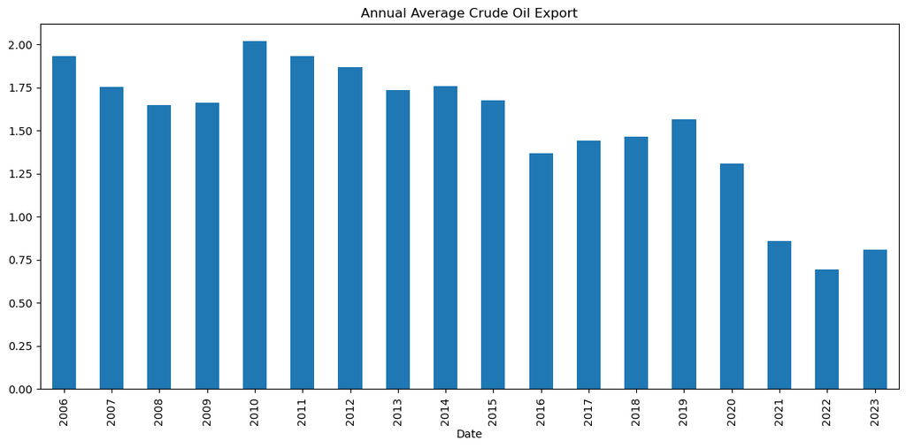

```python
#Annual Average Export
annual_export = df.groupby(df.index.year)['Crude Oil Export'].mean()

annual_export.plot(kind='bar',
                   figsize=(14,6))

plt.title("Annual Average Crude Oil Export")

plt.show()
```

# Interpretation

Annual export averages closely mirror the production pattern throughout the study period, reflecting the near-perfect correlation between the two series. Exports remained relatively high in the late 2000s and early 2010s (averaging approximately 1.80 mbpd in 2006–2010 and 1.79 mbpd in 2011–2015) before declining in tandem with output, falling to about 1.46 mbpd in 2016–2019 and further to an average of only 0.92 mbpd in 2020–2023. The lowest annual export level occurred in 2022 at 0.69 mbpd. This tight correspondence confirms that Nigeria’s crude oil export performance is almost entirely determined by domestic production capacity.

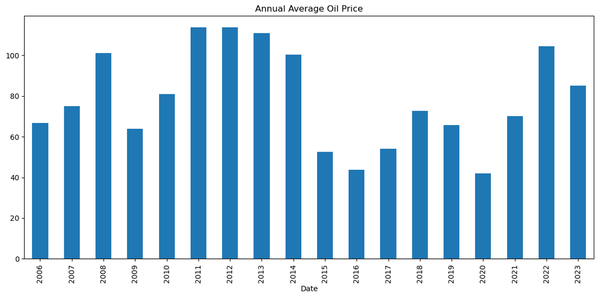

```python
#Annual Average Oil Price
annual_price = df.groupby(df.index.year)['Crude Oil Price'].mean()

annual_price.plot(kind='bar',
                  figsize=(14,6))

plt.title("Annual Average Oil Price")

plt.show()
```

# Interpretation

Unlike production and exports, annual average oil prices exhibit pronounced cycles rather than a consistent long-term upward or downward trend. Prices rose sharply from an average of 66.7 USD/barrel in 2006 to a peak of 101.0 USD/barrel in 2008, then fell during the global financial crisis before recovering strongly to around 110–114 USD/barrel in 2011–2013. A major collapse followed in 2015–2016, when annual averages dropped to 52.7 and 43.8 USD/barrel respectively. Prices remained subdued through 2020 (41.9 USD/barrel) amid the COVID-19 demand shock, before recovering to 104.6 USD/barrel in 2022 and moderating to 85.0 USD/barrel in 2023. These cycles are driven primarily by international market conditions, geopolitical events and global demand fluctuations rather than by domestic Nigerian factors.

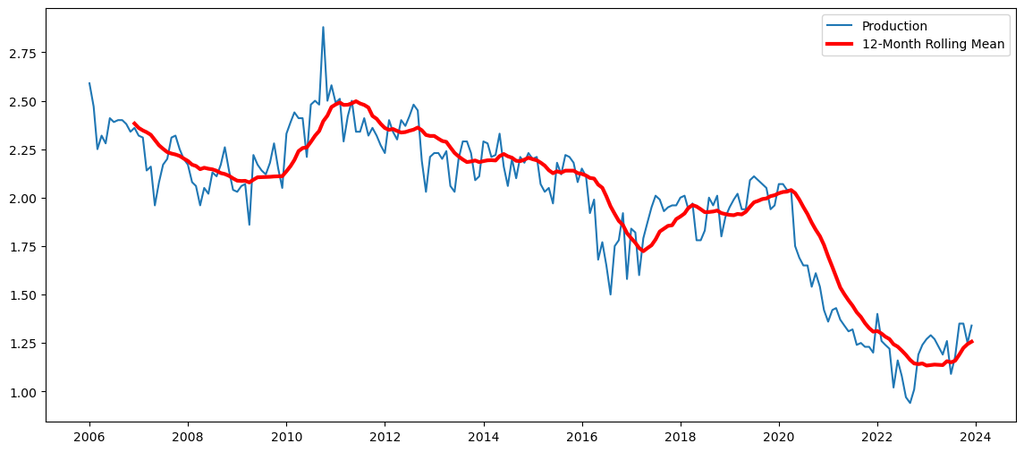

```python
#Rolling Mean
rolling = df["Production"].rolling(12).mean()

plt.figure(figsize=(14,6))

plt.plot(df["Production"], label="Production")

plt.plot(rolling,
         color="red",
         linewidth=3,
         label="12-Month Rolling Mean")

plt.legend()

plt.show()
```

# Interpretation

The twelve-month rolling mean smooths short-term monthly fluctuations and reveals the underlying long-term production trend more clearly. The smoothed series confirms a persistent decline in average production over the study period: relatively elevated levels in the late 2000s and early 2010s give way to a gradual downward shift after 2015 and a sharper fall from 2020 onward. By reducing the influence of month-to-month volatility caused by temporary shutdowns, maintenance or security incidents, the rolling average provides a clearer view of the structural erosion in Nigeria’s production capacity.

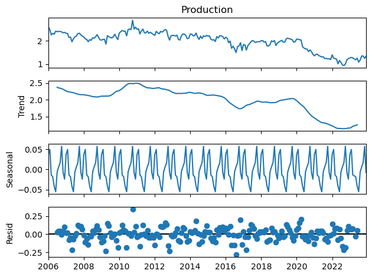

```python
#Seasonal Decomposition
decomposition = seasonal_decompose(
    df["Production"],
    model="additive",
    period=12
)

decomposition.plot()

plt.show()
```

# Interpretation

Seasonal decomposition separates crude oil production into four components: the observed series, the long-term trend, the seasonal component, and the residual. The trend component reveals a clear gradual decline in production across the 2006–2023 period, accelerating after 2015 and becoming more pronounced from 2020 onward. The seasonal component is relatively small in magnitude, indicating that production is not strongly driven by regular monthly cycles and that seasonality plays only a limited role. The residual component captures irregular, non-systematic movements arising from unexpected shocks such as production outages, pipeline vandalism, security incidents in the Niger Delta, or abrupt policy interventions. Overall, the decomposition demonstrates that long-term structural factors—rather than seasonal patterns—dominate the behaviour of Nigeria’s crude oil production.

```python
#Stationarity Test
result = adfuller(df["Production"])

print("ADF Statistic:", result[0])

print("P-value:", result[1])
```

```
ADF Statistic: -1.076306086500952
P-value: 0.7244276929538304
```

The Augmented Dickey–Fuller (ADF) test evaluates the null hypothesis that a unit root is present in the series (i.e., that the series is non-stationary). With a test statistic of −1.0763 and a p-value of 0.7244—well above the conventional 0.05 significance level—the null hypothesis cannot be rejected. Consequently, the production series is judged to be non-stationary: its mean, variance or autocovariance structure changes over time. Non-stationary series violate the assumptions underlying standard ARIMA models and must therefore be differenced (or otherwise transformed) to achieve stationarity before reliable model estimation and forecasting can proceed.

```python
#Differencing
production_diff = df["Production"].diff().dropna()
```

```python
#Train-Test Split
train = df["Production"][:-12]

test = df["Production"][-12:]
```

```python
#Building the ARIMA Model
model = ARIMA(train,
              order=(1,1,1))

model_fit = model.fit()

print(model_fit.summary())
```

```
                               SARIMAX Results
==============================================================================
Dep. Variable:             Production   No. Observations:                  203
Model:                 ARIMA(1, 1, 1)   Log Likelihood                 158.289
Date:                Sun, 02 Aug 2026   AIC                           -310.578
Time:                        00:03:08   BIC                           -300.653
Sample:                    01-01-2006   HQIC                          -306.562
                         - 11-01-2022
Covariance Type:                  opg
==============================================================================
                 coef    std err          z      P>|z|      [0.025      0.975]
------------------------------------------------------------------------------
ar.L1          0.2132      0.205      1.039      0.299      -0.189       0.615
ma.L1         -0.5296      0.178     -2.975      0.003      -0.879      -0.181
sigma2         0.0122      0.001     11.755      0.000       0.010       0.014
===================================================================================
Ljung-Box (L1) (Q):                   0.05   Jarque-Bera (JB):                 8.13
Prob(Q):                              0.82   Prob(JB):                         0.02
Heteroskedasticity (H):               0.59   Skew:                            -0.00
Prob(H) (two-sided):                  0.03   Kurtosis:                         3.98
===================================================================================

Warnings:
[1] Covariance matrix calculated using the outer product of gradients (complex-step).
```

# Interpretation

The selected ARIMA(1,1,1) specification comprises one autoregressive term (AR = 1), first-order differencing (d = 1) to achieve stationarity, and one moving-average term (MA = 1). Key parameter results show that the MA coefficient is statistically significant (p = 0.003), indicating that recent forecast errors exert a meaningful influence on current predictions. In contrast, the AR coefficient is not statistically significant (p = 0.299), suggesting that the immediate past value of production has only a weak direct effect once the series has been differenced. The model’s AIC of −310.58 provides a useful benchmark for comparison with alternative specifications; lower AIC values indicate relatively better fit.Diagnostic checks further support the model’s adequacy: the Ljung–Box test (p = 0.82) finds no significant residual autocorrelation, confirming that the ARIMA(1,1,1) has successfully captured the serial dependence in the data. However, the Jarque–Bera test (p = 0.02) indicates that the residuals depart somewhat from normality, and evidence of heteroskedasticity points to changing residual variance over time. These findings suggest that while the ARIMA(1,1,1) is an acceptable baseline, more flexible specifications such as SARIMA or Prophet may better accommodate the remaining non-normality and variance dynamics in Nigeria’s crude oil production series.

```python
#forecast
forecast = model_fit.forecast(steps=12)
```

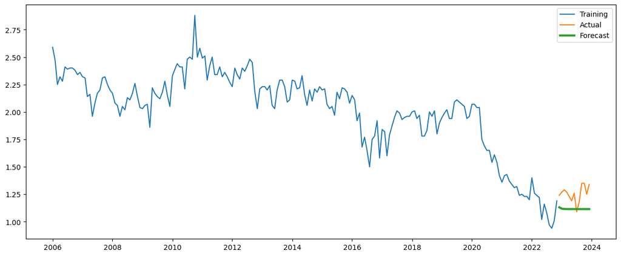

```python
#Plot Forecast
plt.figure(figsize=(15,6))

plt.plot(train.index,
         train,
         label="Training")

plt.plot(test.index,
         test,
         label="Actual")

plt.plot(test.index,
         forecast,
         label="Forecast",
         linewidth=3)

plt.legend()

plt.show()
```

```python
#Model Evaluation
mae = mean_absolute_error(test, forecast)

rmse = np.sqrt(mean_squared_error(test, forecast))

print("MAE:", mae)

print("RMSE:", rmse)
```

```
MAE: 0.14428235649664953
RMSE: 0.15826740773324044
```

# Interpretation

The mean absolute error (MAE) of 0.1443 indicates that, on average, the model’s forecasts deviate from actual production by approximately 0.14 million barrels per day. The root mean squared error (RMSE) of 0.1583 is only modestly higher, implying that large individual forecast errors are relatively uncommon. Relative to the historical mean production of approximately 1.98 mbpd, these error magnitudes represent a satisfactory level of predictive accuracy for a baseline ARIMA model and provide a solid foundation for short-term forecasting of Nigeria’s crude oil output.

```python
#Forecast Next 12 Months
final_model = ARIMA(
    df["Production"],
    order=(1,1,1)
)

final_model = final_model.fit()

future = final_model.forecast(steps=12)

future_dates = pd.date_range(
    start=df.index[-1] + pd.DateOffset(months=1),
    periods=12,
    freq="MS"
)

future_forecast = pd.DataFrame({
    "Date": future_dates,
    "Forecast Production": future.values
})

future_forecast
```

|  | Date | Forecast Production |
| --- | --- | --- |
| 0 | 2024-01-01 | 1.320373 |
| 1 | 2024-02-01 | 1.315491 |
| 2 | 2024-03-01 | 1.314277 |
| 3 | 2024-04-01 | 1.313975 |
| 4 | 2024-05-01 | 1.313900 |
| 5 | 2024-06-01 | 1.313881 |
| 6 | 2024-07-01 | 1.313876 |
| 7 | 2024-08-01 | 1.313875 |
| 8 | 2024-09-01 | 1.313875 |
| 9 | 2024-10-01 | 1.313875 |
| 10 | 2024-11-01 | 1.313875 |
| 11 | 2024-12-01 | 1.313875 |

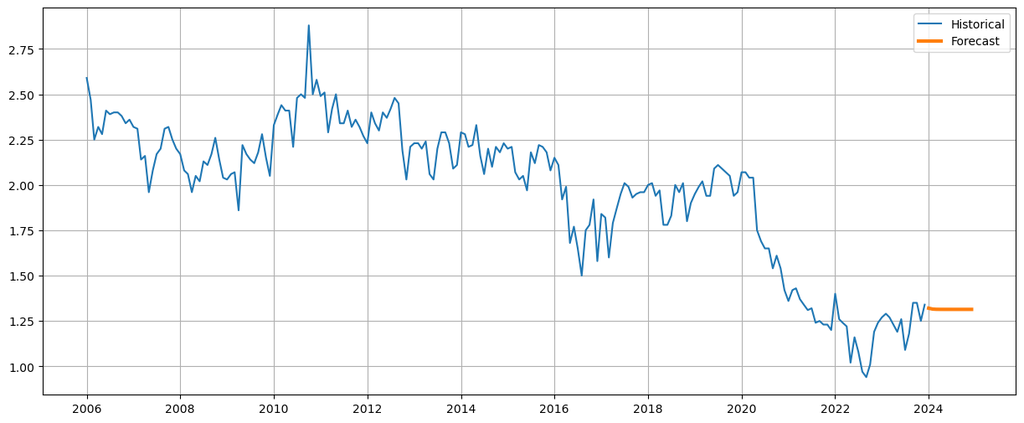

```python
# Plotting the forecast
plt.figure(figsize=(15,6))

plt.plot(df.index,
         df["Production"],
         label="Historical")

plt.plot(future_dates,
         future,
         label="Forecast",
         linewidth=3)

plt.legend()

plt.grid(True)

plt.show()
```

# Interpretation

This pattern is characteristic of ARIMA forecasts, which, after differencing, tend to converge toward a stable long-run mean when no strong residual trend remains. Under the assumption that historical dynamics continue and no major structural breaks occur, the model projects that Nigeria’s crude oil production will remain relatively stable in the region of 1.30–1.33 million barrels per day—well below the historical averages of 2.0–2.5 mbpd recorded in earlier years. From an economic standpoint, sustained output at these levels would translate into correspondingly lower export volumes and reduced government oil revenues relative to periods when production exceeded 2.0 mbpd. The forecast therefore underscores the urgency of addressing the underlying production constraints—ageing infrastructure, security challenges in the Niger Delta, oil theft, and insufficient investment—if Nigeria is to raise future output and strengthen fiscal and foreign-exchange outcomes.

# Summary:

The analysis demonstrates that Nigeria's crude oil production experienced substantial variability between 2006 and 2023, influenced by both domestic operational factors and external market conditions. The series is non-stationary and required differencing before forecasting. The ARIMA(1,1,1) model produced reasonable forecasts with relatively low prediction errors, indicating its usefulness as a baseline forecasting approach. However, the diagnostics and the flat long-term forecast suggest that more advanced models, such as SARIMA, SARIMAX (incorporating oil prices as an external variable), or Prophet, could provide improved forecasts by capturing seasonal patterns, exogenous influences, and structural changes in the Nigerian oil sector.